## Title: Machine Learning Project - Week4

### Output: html_document

### Introduction:

##### The objective of this project is to analyze the data to determine how well 6 participants perform by using accelerometers on the belt, forearm and arm.

### Install packages:

```r
library(AppliedPredictiveModeling)
library(caret)
library(rattle)
```

```r
library(rpart.plot)
library(randomForest)
library(lattice)
library(ggplot2)
library(MASS)
library(klaR)
```

### Download Data for Training and Testing:

```r
valtrain<-"https://d396qusza40orc.cloudfront.net/predmachlearn/pml-training.csv"
valtest<-"https://d396qusza40orc.cloudfront.net/predmachlearn/pml-testing.csv"
```

### Read datasets Files:

```r
setwd("~/Data Science/Machine Learning/Project")
training<- read.csv("training.csv",na.strings=c("NA","#DIV/0!",""))
```

```r
setwd("~/Data Science/Machine Learning/Project")
testing<- read.csv("testing.csv",na.strings=c("NA","#DIV/0!",""))
```

### Print the Dimension of the datasets

```r
dim(training)
```

```
## [1] 19622   160
```

```r
dim(testing)
```

```
## [1]  20 160
```

### Clean the Datasets from useless variables to prevent over-fitting the models:

```r
varTrain<-subset(training,select=c(roll_belt,   pitch_belt, yaw_belt,   total_accel_belt,   gyros_belt_x,   gyros_belt_y,   gyros_belt_z,   accel_belt_x,   accel_belt_y,   accel_belt_z,   magnet_belt_x,  magnet_belt_y,  magnet_belt_z,  roll_arm,   pitch_arm,  yaw_arm,    total_accel_arm,    gyros_arm_x,    gyros_arm_y,    gyros_arm_z,    accel_arm_x,    accel_arm_y,    accel_arm_z,    magnet_arm_x,   magnet_arm_y,   magnet_arm_z,   roll_dumbbell,  pitch_dumbbell, yaw_dumbbell,   total_accel_dumbbell,   gyros_dumbbell_x,   gyros_dumbbell_y,   gyros_dumbbell_z,   accel_dumbbell_x,   accel_dumbbell_y,   accel_dumbbell_z,   magnet_dumbbell_x,  magnet_dumbbell_y,  magnet_dumbbell_z,  roll_forearm,   pitch_forearm,  yaw_forearm,    total_accel_forearm,    gyros_forearm_x,    gyros_forearm_y,    gyros_forearm_z,    accel_forearm_x,    accel_forearm_y,    accel_forearm_z,    magnet_forearm_x,   magnet_forearm_y,   magnet_forearm_z,classe))
```

```r
varTest<-subset(testing,select=c(roll_belt, pitch_belt, yaw_belt,   total_accel_belt,   gyros_belt_x,   gyros_belt_y,   gyros_belt_z,   accel_belt_x,   accel_belt_y,   accel_belt_z,   magnet_belt_x,  magnet_belt_y,  magnet_belt_z,  roll_arm,   pitch_arm,  yaw_arm,    total_accel_arm,    gyros_arm_x,    gyros_arm_y,    gyros_arm_z,    accel_arm_x,    accel_arm_y,    accel_arm_z,    magnet_arm_x,   magnet_arm_y,   magnet_arm_z,   roll_dumbbell,  pitch_dumbbell, yaw_dumbbell,   total_accel_dumbbell,   gyros_dumbbell_x,   gyros_dumbbell_y,   gyros_dumbbell_z,   accel_dumbbell_x,   accel_dumbbell_y,   accel_dumbbell_z,   magnet_dumbbell_x,  magnet_dumbbell_y,  magnet_dumbbell_z,  roll_forearm,   pitch_forearm,  yaw_forearm,    total_accel_forearm,    gyros_forearm_x,    gyros_forearm_y,    gyros_forearm_z,    accel_forearm_x,    accel_forearm_y,    accel_forearm_z,    magnet_forearm_x,   magnet_forearm_y,   magnet_forearm_z,problem_id))
```

### RE-Print the dimension of the new datasets:

```r
dim(varTrain)
```

```
## [1] 19622    53
```

```r
dim(varTest)
```

```
## [1] 20 53
```

### Search for Near Zero Variance that can affect the models:

```r
nsv <- nearZeroVar(varTrain, saveMetrics=TRUE)
nsv
```

```
##                      freqRatio percentUnique zeroVar   nzv
## roll_belt             1.101904     6.7781062   FALSE FALSE
## pitch_belt            1.036082     9.3772296   FALSE FALSE
## yaw_belt              1.058480     9.9734991   FALSE FALSE
## total_accel_belt      1.063160     0.1477933   FALSE FALSE
## gyros_belt_x          1.058651     0.7134849   FALSE FALSE
## gyros_belt_y          1.144000     0.3516461   FALSE FALSE
## gyros_belt_z          1.066214     0.8612782   FALSE FALSE
## accel_belt_x          1.055412     0.8357966   FALSE FALSE
## accel_belt_y          1.113725     0.7287738   FALSE FALSE
## accel_belt_z          1.078767     1.5237998   FALSE FALSE
## magnet_belt_x         1.090141     1.6664968   FALSE FALSE
## magnet_belt_y         1.099688     1.5187035   FALSE FALSE
## magnet_belt_z         1.006369     2.3290184   FALSE FALSE
## roll_arm             52.338462    13.5256345   FALSE FALSE
## pitch_arm            87.256410    15.7323412   FALSE FALSE
## yaw_arm              33.029126    14.6570176   FALSE FALSE
## total_accel_arm       1.024526     0.3363572   FALSE FALSE
## gyros_arm_x           1.015504     3.2769341   FALSE FALSE
## gyros_arm_y           1.454369     1.9162165   FALSE FALSE
## gyros_arm_z           1.110687     1.2638875   FALSE FALSE
## accel_arm_x           1.017341     3.9598410   FALSE FALSE
## accel_arm_y           1.140187     2.7367241   FALSE FALSE
## accel_arm_z           1.128000     4.0362858   FALSE FALSE
## magnet_arm_x          1.000000     6.8239731   FALSE FALSE
## magnet_arm_y          1.056818     4.4439914   FALSE FALSE
## magnet_arm_z          1.036364     6.4468454   FALSE FALSE
## roll_dumbbell         1.022388    84.2065029   FALSE FALSE
## pitch_dumbbell        2.277372    81.7449801   FALSE FALSE
## yaw_dumbbell          1.132231    83.4828254   FALSE FALSE
## total_accel_dumbbell  1.072634     0.2191418   FALSE FALSE
## gyros_dumbbell_x      1.003268     1.2282132   FALSE FALSE
## gyros_dumbbell_y      1.264957     1.4167771   FALSE FALSE
## gyros_dumbbell_z      1.060100     1.0498420   FALSE FALSE
## accel_dumbbell_x      1.018018     2.1659362   FALSE FALSE
## accel_dumbbell_y      1.053061     2.3748853   FALSE FALSE
## accel_dumbbell_z      1.133333     2.0894914   FALSE FALSE
## magnet_dumbbell_x     1.098266     5.7486495   FALSE FALSE
## magnet_dumbbell_y     1.197740     4.3012945   FALSE FALSE
## magnet_dumbbell_z     1.020833     3.4451126   FALSE FALSE
## roll_forearm         11.589286    11.0895933   FALSE FALSE
## pitch_forearm        65.983051    14.8557741   FALSE FALSE
## yaw_forearm          15.322835    10.1467740   FALSE FALSE
## total_accel_forearm   1.128928     0.3567424   FALSE FALSE
## gyros_forearm_x       1.059273     1.5187035   FALSE FALSE
## gyros_forearm_y       1.036554     3.7763735   FALSE FALSE
## gyros_forearm_z       1.122917     1.5645704   FALSE FALSE
## accel_forearm_x       1.126437     4.0464784   FALSE FALSE
## accel_forearm_y       1.059406     5.1116094   FALSE FALSE
## accel_forearm_z       1.006250     2.9558659   FALSE FALSE
## magnet_forearm_x      1.012346     7.7667924   FALSE FALSE
## magnet_forearm_y      1.246914     9.5403119   FALSE FALSE
## magnet_forearm_z      1.000000     8.5771073   FALSE FALSE
## classe                1.469581     0.0254816   FALSE FALSE
```

##### No NSV’s at this point (TRUE)…

### Build the Models:

##### Firs of all, we want create a partition to separate the Training/Testing data from the Training dataset (varTrain). Once this is performed, we would like to analyze the data by using, at least, two different models. The analysis will allow us to determine which one of the models is more accurate. Ones the best model is selected, we can use that model to reference back to the Testing dataset (varTest), so we can predict the outcome of “Classe”

```r
set.seed(300)
```

```r
subsamples <- createDataPartition(y=varTrain$classe, p=0.75, list=FALSE)
subTraining <- varTrain[subsamples, ]
subTesting <- varTrain[-subsamples, ]
```

### Print the Dimension of the sub-datasets:

```r
dim(subTraining)
```

```
## [1] 14718    53
```

```r
dim(subTesting)
```

```
## [1] 4904   53
```

### Build the first model:

##### We’ll use “train” from the “Caret” package to sets up a grid of tuning parameters for a number of classification and regression routines. The preferred method for this trial will be Recursive Partitioning and Regression Trees (rpart)

```r
modelFit1 <- train(classe ~ .,method="rpart",data=subTraining)
```

##### Calculate a cross-tabulation of observed and predicted classes with associated statistics. At this point, I’m interested in calculating how accurate this model is

```r
confusionMatrix(subTesting$classe,predict(modelFit1,subTesting))$overall[1]
```

```
## Accuracy
## 0.504894
```

##### I like to print the outcome by using the object “finalModel” to refit with the whole dataset after the different levels of “Classe” were optimized using resampling technique. The results show these levels’ weights in relation to the variables

```r
print(modelFit1$finalModel)
```

```
## n= 14718
##
## node), split, n, loss, yval, (yprob)
##       * denotes terminal node
##
##  1) root 14718 10533 A (0.28 0.19 0.17 0.16 0.18)
##    2) roll_belt< 130.5 13491  9318 A (0.31 0.21 0.19 0.18 0.11)
##      4) pitch_forearm< -33.95 1188     7 A (0.99 0.0059 0 0 0) *
##      5) pitch_forearm>=-33.95 12303  9311 A (0.24 0.23 0.21 0.2 0.12)
##       10) magnet_dumbbell_y< 432.5 10366  7453 A (0.28 0.18 0.24 0.19 0.11)
##         20) roll_forearm< 122.5 6435  3830 A (0.4 0.18 0.19 0.17 0.062) *
##         21) roll_forearm>=122.5 3931  2653 C (0.078 0.18 0.33 0.23 0.19) *
##       11) magnet_dumbbell_y>=432.5 1937   960 B (0.041 0.5 0.044 0.22 0.19) *
##    3) roll_belt>=130.5 1227    12 E (0.0098 0 0 0 0.99) *
```

##### Now we can plot this information to make it more graphical:

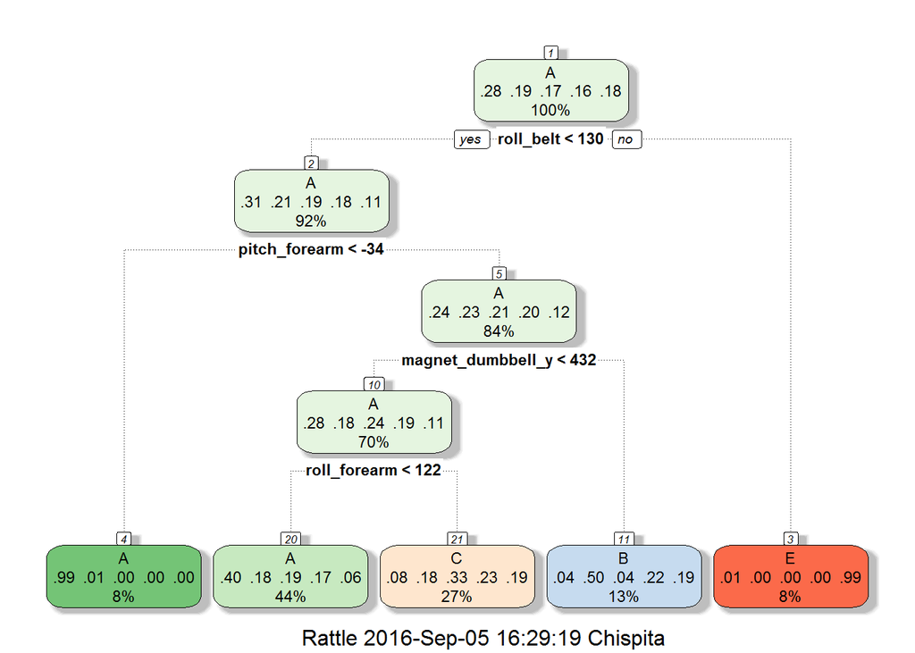

```r
fancyRpartPlot(modelFit1$finalModel)
```

### Build the second model:

```r
modelFit2 <- randomForest(classe ~. , data=subTraining, method="rf")
```

```r
confusionMatrix(subTesting$classe,predict(modelFit2,subTesting))$overall[1]
```

```
##  Accuracy
## 0.9971452
```

##### The “randomeForest” model it’s more accurate than “train”. Thus, we’ll use the second model to reference back the testing dataset (varTest)

```r
print(modelFit2$finalModel)
```

##### Random forest can’t be run with finalModel because is the best prediction itself, so result = NULL

### Final prediction

##### Make the final prediction by inserting the random forest model into the predict fucntion:

```r
finalPrediction<-predict(modelFit2,varTest)
finalPrediction
```

```
##  1  2  3  4  5  6  7  8  9 10 11 12 13 14 15 16 17 18 19 20
##  B  A  B  A  A  E  D  B  A  A  B  C  B  A  E  E  A  B  B  B
## Levels: A B C D E
```

##### This results show the predicted “classe” on each one of the trials of the testing dataset.